# Assign1

Asgharagha

December 19, 2015

The goal of this project is to examine a data set obtained from a personal activity monitoring device.

## Loading and preprocessing the data

To load data:

```r
actdata <- read.csv("activity.csv")
str(actdata)
```

```
## 'data.frame':    17568 obs. of  3 variables:
##  $ steps   : int  NA NA NA NA NA NA NA NA NA NA ...
##  $ date    : Factor w/ 61 levels "2012-10-01","2012-10-02",..: 1 1 1 1 1 1 1 1 1 1 ...
##  $ interval: int  0 5 10 15 20 25 30 35 40 45 ...
```

## What is mean total number of steps taken per day?

For this section, it is necessary to aggregate the data:

```r
actdata2 <- aggregate(steps ~ date, data = actdata, sum, na.rm = TRUE)
colnames(actdata2) <- c("date","steps")
str(actdata2)
```

```
## 'data.frame':    53 obs. of  2 variables:
##  $ date : Factor w/ 61 levels "2012-10-01","2012-10-02",..: 2 3 4 5 6 7 9 10 11 12 ...
##  $ steps: int  126 11352 12116 13294 15420 11015 12811 9900 10304 17382 ...
```

To calculate the mean total number of steps taken per day:

```r
mean(actdata2$steps)
```

```
## [1] 10766.19
```

and make a histogram of the total number of steps taken each day:

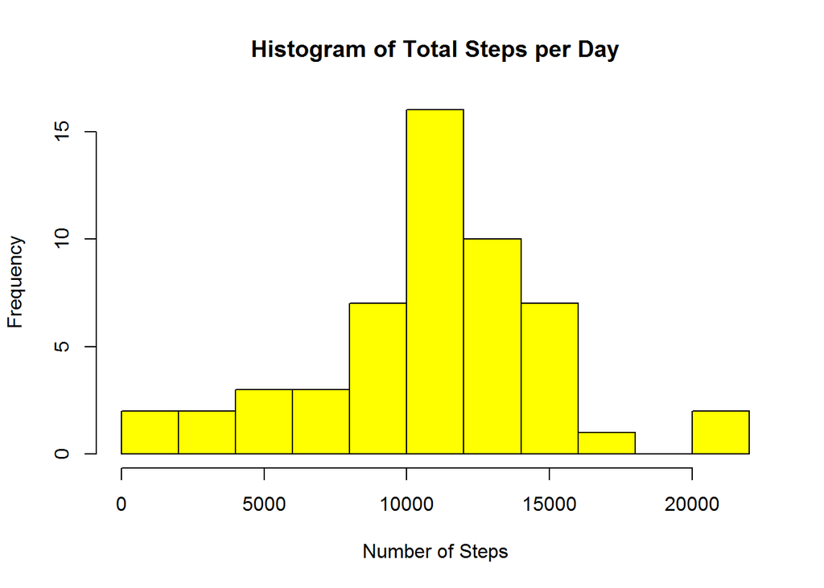

```r
hist(actdata2$steps, breaks = 10, main = "Histogram of Total Steps per Day", xlab = "Number of Steps", col = "yellow")
```

and the median total number of steps taken per day is:

```r
median(actdata2$steps)
```

```
## [1] 10765
```

So the mean is 10766.19 steps and median is 10765 steps.

## What is the average daily activity pattern?

To process the data:

```r
actdata3 <- tapply(actdata$steps, actdata$interval, mean, na.rm = TRUE)
```

The plot can now be created:

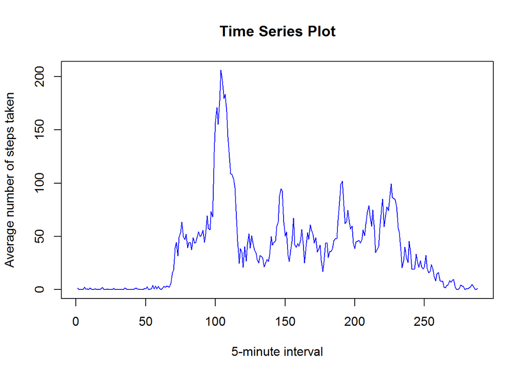

```r
plot(actdata3, type = "l", xlab = "5-minute interval", ylab = "Average number of steps taken", main = "Time Series Plot", col = "blue")
```

To obtain the 5-minute interval with the maximum number of steps:

```r
names(which.max(actdata3))
```

```
## [1] "835"
```

## Imputing missing values

The total number of missing values in the dataset (i.e. the total number of rows with NAs) can be obtained by:

```r
sum(is.na(actdata))
```

```
## [1] 2304
```

For filling in all of the missing values in the dataset, my strategy is to use mean in 5 min interval (actdata4 shows the new created data set):

```r
mean_intervals <- aggregate(actdata$steps, by=list(actdata$interval), mean, na.rm=TRUE)
names(mean_intervals) = c('interval', 'steps')
actdata4 = actdata
           for (i in 1:nrow(actdata4)) {if (is.na(actdata4$steps[i])) {
                int = actdata4$interval[i]
                sub = subset(mean_intervals, interval == int)
                actdata4$steps[i] = sub$steps} }
str(actdata4)
```

```
## 'data.frame':    17568 obs. of  3 variables:
##  $ steps   : num  1.717 0.3396 0.1321 0.1509 0.0755 ...
##  $ date    : Factor w/ 61 levels "2012-10-01","2012-10-02",..: 1 1 1 1 1 1 1 1 1 1 ...
##  $ interval: int  0 5 10 15 20 25 30 35 40 45 ...
```

```r
sum(is.na(actdata4))
```

```
## [1] 0
```

The next step is to To calculate the mean and median total number of steps taken per day and make a histogram of the new data:

```r
actdata5 <- aggregate(steps ~ date, data = actdata4, sum)
colnames(actdata5) <- c("date","steps")
mean(actdata5$steps)
```

```
## [1] 10766.19
```

```r
median(actdata5$steps)
```

```
## [1] 10766.19
```

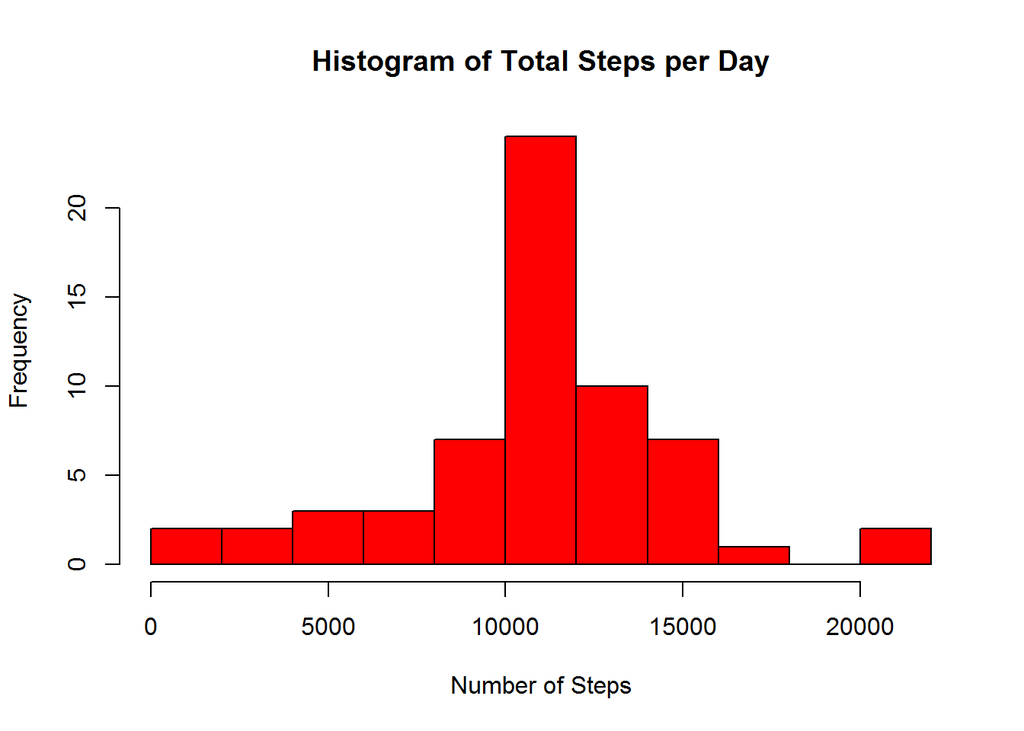

```r
hist(actdata5$steps, breaks = 10, main = "Histogram of Total Steps per Day", xlab = "Number of Steps", col = "red")
```

Interestingly, the updated mean is not changed (10766.19), but the median value for new data (10766.19) is a little bit more than the actual data (10765).

## Are there differences in activity patterns between weekdays and weekends?

The new variable can be created by:

```r
actdata4$date <- as.Date(actdata4$date, "%Y-%m-%d")
day <- weekdays(actdata4$date)
day_level <- vector()
for (i in 1:nrow(actdata4)) {
    if (day[i] == "Saturday" | day[i] == "Sunday") {
        day_level[i] <- "Weekend"
    } else {
        day_level[i] <- "Weekday"
    }
}
actdata4$day_level <- day_level
actdata4$day_level <- factor(actdata4$day_level)
```

Alright! panel data can now be created by:

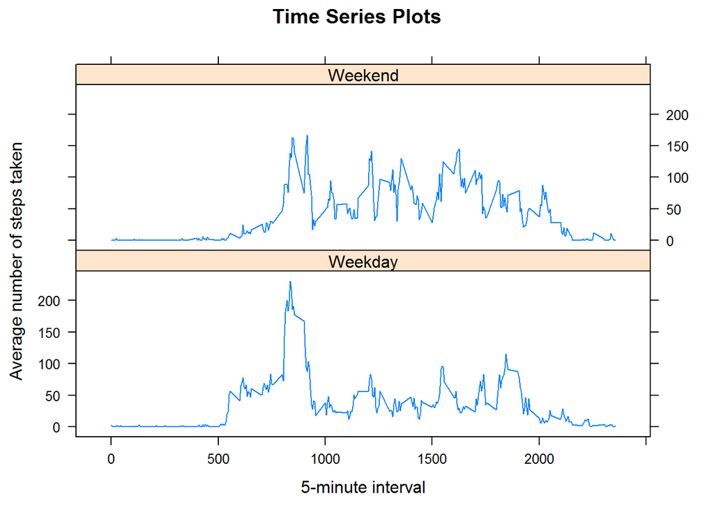

```r
actdata6 <- aggregate(steps ~ interval + day_level, data = actdata4, mean)
names(actdata6) <- c("interval", "daylevel", "steps")
library(lattice)
xyplot(steps ~ interval | daylevel, actdata6, type = "l", layout = c(1, 2), xlab = "5-minute interval", ylab = "Average number of steps taken", main = "Time Series Plots")
```

As seen in the plots, the activity patterns between weekdays and weekends are different.